Skip to contents

# Coffee Field Model: One Field, One Policy, One Run

Source: [`vignettes/coffee_field_model.Rmd`](https://github.com/Dustin-Wood/funfield/blob/main/vignettes/coffee_field_model.Rmd)

## What is a functional field?

A **functional field** is a model of how situational forces propagate through an environment to produce action outcomes. At each moment the field specifies which forces are *afforded* — which causal pathways are open given the current state of the situation. A later step only matters once an earlier step has changed the situation: this is **causal gating**, and it is what turns a four-step plan into a connected causal chain rather than four independent intentions.

The same field `F` supports two complementary workflows. **Induction** runs data → `F`: you fit the field’s coefficients from observed behaviour with `pathXMY()` and friends. **Deduction** runs `F` → behaviour: you treat the coefficients as a working theory and *simulate* forward to see what a plan produces. This vignette is about deduction. For the notation it uses throughout — the `F` field object and the `fZ_X.Y` parameter schema — see `vignette("notation", package = "funfield")`.

The worked example is making a cup of drip coffee: ready your supplies, turn the machine on, pour, sip. The whole vignette rests on one clean separation:

- the **field** is the *physics* — how actions and states move other states and outcomes, including what each action *uses up* and what it *costs*. It exists whether or not anyone acts.
- the **policy** is the *plan* — which action the agent is willing to take, and when.

`simulateF()` runs a policy on a field as a **turn-based process**: each turn it finds the actions whose conditions are met, fires **one** of them, lets its effects settle, and moves on — until no action is eligible. Because actions enter one at a time, the *same run* answers both questions you can ask of a plan: **what does it ultimately afford?** (read the final value) and **how does it unfold in time?** (read the whole trajectory).

## The smallest field: prepare, then do

Before the full coffee process, here is the whole idea in miniature — two actions and the gate between them.

Many plans have a step whose only job is to make a *later* step work: you must **prepare** the ground before the **doing** pays off. The smallest field that captures this has two actions, `Prep` and `Do`, tied together by a single rule — `Do`’s effect is **gated** on what `Prep` produces:

- `Prep` produces a state `Ready` — the preparation.
- `Do` produces the outcome `Done`, but **only when `Ready` is on**. Written as the afforded force `Done ~ Ready:Do`, the `Do → Done` push is zero until `Prep` has set `Ready`.
- `Done` is what the agent values (`L ~ Done`).

```r
library(funfield)

pd_field <- labelF("
  Ready ~ 1 * Prep      + use * Ready:Do
  Done  ~ 1 * Ready:Do
  L     ~ 1 * Done
", actions = c("Prep", "Do"))
pd_field$params["use"] <- -1

cat(pd_field$model)
```

```
#> Ready ~ f1_Prep.Ready * Prep + use * Ready:Do
#> Done ~ fReady_Do.Done * Ready:Do
#> L ~ f1_Done.L * Done
```

The afforded force `Done ~ Ready:Do` is the gate; the `use` term lets `Do` **consume** `Ready` (so once you have done the thing, the preparation is spent and the run settles). The policy is two rules — prepare on the agent’s intention, do once ready:

```r
pd_plan <- planF("
  Prep ~ choice   # ready the ground
  Do   ~ Ready    # do the thing, once ready
", label = "A")
pd_plan
```

```
#> Plan A
#>  step rule          description
#>  a1   Prep ~ choice ready the ground
#>  a2   Do ~ Ready    do the thing, once ready
```

```r
pd_s0 <- c(choice = 1, Prep = 0, Ready = 0, Do = 0, Done = 0, L = 0)

pd_out <- simulateF(pd_field$model, pd_field$params, pd_s0, pd_plan,
                    flows = "choice")
pd_out$fired
```

```
#> [1] "Prep" "Do"
```

```r
round(pd_out$trajectory, 2)
```

```
#>     choice Prep Ready Do Done L
#> t=0      1    0     0  0    0 0
#> t=1      0    1     1  0    0 0
#> t=2      0    0     0  1    1 1
```

The policy is wrapped as a `planF()` object: it carries the same `action ~ condition` rules but pins each to an ordered **step label** (`a1`, `a2`) and a short **description**, which the diagram below writes out as a corner **plan-list**. A `planF` stands in for the raw policy string anywhere the engine takes one — here in `simulateF()`.

`Prep` fires first (its trigger `choice` is on), setting `Ready` at turn 1; that makes `Do` eligible, and at turn 2 `Do` produces `Done` — spending `Ready` as it goes — so `L` reaches `1`. Now skip the preparation and reach straight for `Do`:

```r
pd_skip <- simulateF(pd_field$model, pd_field$params, pd_s0,
                     "Do ~ 1 * choice", flows = "choice")
pd_skip$fired
```

```
#> [1] "Do"
```

```r
pd_skip$trajectory[, "L"]
```

```
#> t=0 t=1
#>   0   0
```

`Do` *does* fire — but `Ready` was never set, so the gated force stays shut, `Done` never moves, and `L` stays `0`. **Doing without preparing is empty motion.** That gap is the whole point of the primitive, and the coffee pipeline below is just this shape repeated four times over.

**Reading the diagram.** Three colour languages run side by side, kept apart so they never blur. Two of them live on the **forces**, and only one extra colour is ever added to a **node**:

- **green = the action plan’s forces** (“green means go”) — the policy edge that fires each action, and its step label (the `planF` numbers them `a1`, `a2`). The action *nodes* themselves stay on the value scale. The whole plan is also written out as a **plan-list** in the upper-left corner, each step in its arrow’s green, and the step currently firing shown in **bold**.
- **gold = a condition** — a state that *gates* a later force. Here the condition is the one place a node takes a non-value colour: the gating state, the force it opens, and that force’s label all share the gold. The force is light grey while the gate is shut (a *potential* path) and turns gold the instant the gate opens.
- **red–white–blue = value** for every other node — the actions, the outcome `done`, and `L` — white at zero, blue as they fill.

The diagram reads as a **staircase**: a policy edge runs level (from a condition to the action it fires), then the action’s force climbs diagonally up to the next state; `L` sits back down at the starting level, so the diagram closes where it began. Step through with **← Back** / **Forward →** and watch the `do → done` force: grey at the start (it needs `ready`), gold the moment `prep` sets `ready`, then `do` fires, `done` lights, and `ready` is spent — the gate closing behind it.

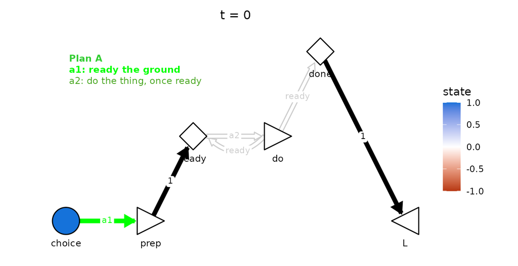

```r
pd_model  <- paste(pd_field$model, pd_plan$policy, sep = "\n")
pd_layout <- data.frame(
  name  = c("choice", "Prep", "Ready", "Do", "Done", "L"),
  x     = c(0,        2,      3,       5,    6,      8),
  y     = c(0,        0,      2,       2,    4,      0),
  shape = c("circle", "rtTri", "diamond", "rtTri", "diamond", "lfTri"),
  label = c("choice", "prep", "ready", "do", "done", "L"),
  stringsAsFactors = FALSE)

pd_steps  <- nrow(pd_out$trajectory) - 1L
pd_frames <- lapply(0:pd_steps, function(t) {
  plotField(pd_model, pd_field$params, pd_out$trajectory[paste0("t=", t), ],
            pd_layout, plan = pd_plan, plan_ramp = TRUE,
            condition_ramp = TRUE, title = paste("t =", t))
})

plotsAsWidget(pd_frames, panel_titles = paste("Step", 0:pd_steps),
              width = 7, height = 3.6)
```

Frame 1 of 3

## Step 1: The field

Each stage of the coffee process is an **afforded force**: a path that contributes nothing until its prerequisite state is on. In the `fZ_X.Y` schema that is a term with a moderator but no baseline — `fZ_X.Y * X:Z` — so the `X → Y` force is zero whenever `s[Z] = 0` and switches on once `s[Z]` turns positive.

The physical chain of afforded forces:

| Force | Afforded by | Reads as |
| --- | --- | --- |
| `make → s2` | — | making the rig sets it up (the entry point) |
| `TurnOn → HCoPot` | `s2` | turning it on brews into the pot once the rig is ready |
| `Pour → HCoCup` | `HCoPot` | pouring fills the cup once there’s coffee in the pot |
| `Sip → HCo` | `HCoCup` | sipping yields “having coffee” once it’s in the cup |

A real process also **uses things up**: once the machine has brewed, the set-up rig (`s2`) is spent; once you pour, the coffee leaves the pot. We write each consumption as an **outflow term with a shared negative coefficient** `use`, e.g. `use * s2:TurnOn` (“turning on consumes the rig”). Production and consumption together make every object state a balance: it rises when its action produces it and falls when the next action draws it down.

Two more forces close the field: **value** and **cost**.

The terminal node is **`L`** — likelihood. In ESJT data `L` is the rated likelihood of taking an action; here it plays the role an economist would give *subjective expected utility*. Value enters through the forces into `L`, and we give it two:

| Force | Coefficient | Reads as |
| --- | --- | --- |
| `HCo → L` | `.9` | having consumed coffee is most of what the agent is after |
| `Energy → L` | `.1` | all else equal, the agent would rather keep its energy |

The vector `f[., L]` — every force into `L` — is the agent’s **values**, its most direct utility function. We keep it normalised so the absolute weights sum to one (`.9 + .1 = 1`), reading as a budget over what the agent cares about.

Cost enters through a new node, **`Energy`**. Every action carries a **performance cost**: doing something — even something futile — spends effort. `costF()` writes that in for us, a flat decrement to `Energy` per action, charged on the bare action node so it is paid whenever the action fires, *whether or not the action accomplishes anything*. Pouring an empty pot still costs effort.

```r
library(funfield)

actions <- c("make", "TurnOn", "Pour", "Sip")

afford <- "
  s2     ~ 1 * make        + use * s2:TurnOn
  HCoPot ~ 1 * s2:TurnOn   + use * HCoPot:Pour
  HCoCup ~ 1 * HCoPot:Pour + use * HCoCup:Sip
  HCo    ~ 1 * HCoCup:Sip
"
cost  <- costF(actions, cost = -0.1)

field <- labelF(paste(afford, cost,
                      "L ~ 0.9 * HCo + 0.1 * Energy", sep = "\n"),
                actions = actions)
field$params["use"] <- -1          # consumption strength (the shared label)

cat(field$model)
```

```
#> s2 ~ f1_make.s2 * make + use * s2:TurnOn
#> HCoPot ~ fs2_TurnOn.HCoPot * s2:TurnOn + use * HCoPot:Pour
#> HCoCup ~ fHCoPot_Pour.HCoCup * HCoPot:Pour + use * HCoCup:Sip
#> HCo ~ fHCoCup_Sip.HCo * HCoCup:Sip
#> Energy ~ f1_make.Energy * make + f1_TurnOn.Energy * TurnOn + f1_Pour.Energy * Pour + f1_Sip.Energy * Sip
#> L ~ f1_HCo.L * HCo + f1_Energy.L * Energy
```

```r
field$params
```

```
#>          f1_make.s2                 use   fs2_TurnOn.HCoPot fHCoPot_Pour.HCoCup
#>                 1.0                -1.0                 1.0                 1.0
#>     fHCoCup_Sip.HCo      f1_make.Energy    f1_TurnOn.Energy      f1_Pour.Energy
#>                 1.0                -0.1                -0.1                -0.1
#>       f1_Sip.Energy            f1_HCo.L         f1_Energy.L
#>                -0.1                 0.9                 0.1
```

`labelF()` gives every fixed force its canonical `fZ_X.Y` label and captures its value; the one parameter it leaves for us is the shared **`use`** label, the consumption strength, which we set to `-1`. Note what is *not* here: no `make`, `TurnOn`, `Pour` or `Sip` ever appears on a left-hand side. **Actions are exogenous** — the field says what each action *would* do; it is the policy, next, that decides which one actually fires.

## Step 2: The policy

A **policy** is a set of `action ~ condition` rules: fire each action once its prerequisite state is present. The first action is launched not by a situational state but by the agent’s **`choice`** to act — a one-shot intention that is spent the moment it sets things in motion. We name this four-step plan **Plan A** and write it as a `planF()` object — the same rules, plus a one-line description of each step:

```r
planA <- planF("
  make   ~ choice    # prepare coffee machine
  TurnOn ~ s2        # once prepared, turn on
  Pour   ~ HCoPot    # when the pot fills, pour over the cup
  Sip    ~ HCoCup    # once the cup is full, take a sip
", label = "A")
planA
```

```
#> Plan A
#>  step rule          description
#>  a1   make ~ choice prepare coffee machine
#>  a2   TurnOn ~ s2   once prepared, turn on
#>  a3   Pour ~ HCoPot when the pot fills, pour over the cup
#>  a4   Sip ~ HCoCup  once the cup is full, take a sip
```

`planF()` numbers the rules in order (`a1 … a4`), keeps each one’s description, and assigns the green ramp colour the diagram will give its arrow — so the run, the edges, and the corner plan-list all draw from one object. To have something to compare against later, we also draft a **faulty** Plan B that skips a step — turning the machine on and reaching for a sip without ever pouring:

```r
planB <- planF("
  make   ~ choice    # prepare coffee machine
  TurnOn ~ s2        # once prepared, turn on
  Sip    ~ HCoCup    # reach for a sip — but the pour never happened
", label = "B")
```

`simulateF()` reads only the *condition variables* of each rule (the coefficients are ignored for eligibility — they are there so the same string can be drawn as edges later). A rule says *when an action is allowed*, not how strong it is.

## Step 3: Run the field

The agent starts committed (`choice = 1`), everything else off:

```r
s_0 <- c(choice = 1, make = 0, s2 = 0, TurnOn = 0, HCoPot = 0,
         Pour = 0, HCoCup = 0, Sip = 0, HCo = 0, Energy = 0, L = 0)

out <- simulateF(field$model, field$params, s_0, planA, flows = "choice")
round(out$trajectory[, c("choice","make","s2","TurnOn","HCoPot",
                         "Pour","HCoCup","Sip","HCo","Energy","L")], 2)
```

```
#>     choice make s2 TurnOn HCoPot Pour HCoCup Sip HCo Energy     L
#> t=0      1    0  0      0      0    0      0   0   0    0.0  0.00
#> t=1      0    1  1      0      0    0      0   0   0   -0.1 -0.01
#> t=2      0    0  0      1      1    0      0   0   0   -0.2 -0.02
#> t=3      0    0  0      0      0    1      1   0   0   -0.3 -0.03
#> t=4      0    0  0      0      0    0      0   1   1   -0.4  0.86
```

```r
out$fired
```

```
#> [1] "make"   "TurnOn" "Pour"   "Sip"
```

One stage per turn, and **each action fires exactly once**. Read a turn left to right:

- **eligibility**: the actions whose condition currently holds. At the start only `make` qualifies (its trigger `choice` is on); the rest are gated on states that do not yet exist.
- **fire one**: of the eligible actions, one fires. Here only one ever qualifies at a time, so the choice is forced; when several qualify, `simulateF()` *appraises* them — simulates each one turn ahead and fires the one that most raises `L` (the deductive job of a choice node).
- **settle**: the field takes one step — the fired action produces the next state and consumes the one that afforded it, and `Energy` takes its `-0.1`. `flows = "choice"` marks `choice` a one-shot, spent once `make` reads it.

Consumption is what keeps the run moving and finite: once `TurnOn` consumes `s2`, `TurnOn` is no longer eligible, so it cannot re-fire; the token simply hands itself down the line. By the last turn `HCo = 1`, `Energy = -0.4` (four actions paid for), and the values vector nets these to `L = .9 \cdot 1 + .1 \cdot (-0.4) = 0.86`. The run ends because nothing is eligible any more:

```r
out$halted
```

```
#> [1] "quiescent"
```

## Step 4: Choosing among plans

The “which plan?” question needs no separate machinery: **run each policy and compare the final value.** That comparison *is* the choice node, one level up from the per-turn appraisal — an argmax over what each plan affords, net of what it costs. `chooseF()` wraps it: run each policy to quiescence, tabulate the final state, and flag the winner. It appends a do-nothing baseline by default.

```r
chooseF(field$model, field$params, s_0,
        policies = list(A = planA, B = planB), flows = "choice")
```

```
#>           plan s2 HCoPot HCoCup HCo Energy     L chosen
#> 1            A  0      0      0   1   -0.4  0.86   TRUE
#> 2            B  0      1      0   0   -0.2 -0.02  FALSE
#> 3 (do nothing)  0      0      0   0    0.0  0.00  FALSE
```

The full plan reaches coffee and, net of cost, earns `L = 0.86`; doing nothing reaches nothing, spends nothing, and earns `L = 0`. The telling row is **`B`**. It makes and turns on — two real actions, so it has spent `Energy = -0.2` — but never pours, so the cup is never filled, the `Sip → HCo` force stays gated shut, and `HCo` stays `0`. With nothing on the value side to show for it, its utility goes **negative** (`L = -0.02`): Plan B scores *below doing nothing*. That is the payoff of accounting for cost — without the energy term the two would tie at `L = 0`; with it they come apart, and inaction wins by conserving effort. Causal gating decides whether a plan reaches the outcome; the cost ledger decides what a *failed* reach is worth.

## Step 5: Watch it unfold

`plotField()` draws the field at one state as a node-link diagram: the **choice point** is a circle, **object** states are diamonds, **actions** right-facing triangles, the **value** readout a left-facing triangle, and **`Energy`** a square holding a ⚡ bolt, set just left of `L` so the value forces from `HCo` (down the staircase) and `Energy` (along the floor) converge on `L`. Each edge encodes its force, with the level printed on the shaft: thicker and darker for larger `|f|`, dashed when negative — so the production forces (`f = 1`) read as strong solid lines and the energy costs (`f = -0.1`) as faint dashed ones. The backward **consumption** arcs bow below their forward edge so they do not overlay it.

The three colour languages from the prep-and-do primer now run the length of the coffee chain, each as its own **staircase**. The **action ramp** is green — passing `planA` as the plan (`plan_ramp = TRUE`), its four moves step from lime to dark green and read `a1, a2, a3, a4` in order. **Plan A** is also written out as a **plan-list** in the upper-left corner — each step in its arrow’s green, and as the run steps through, the step currently firing shown in **bold**, so you can read the plain-language plan alongside the staircase it drives. The **condition ramp** is gold → deep amber (`condition_ramp = TRUE`): the three gating states (`rig set`, `coffee in pot`, `coffee in cup`) darken from gold to amber as you climb, each sharing its colour with the force it opens. And everything left over — the value readout `L`, the cost ledger `Energy`, and the bare production forces — keeps the diverging **red–white–blue** value scale. So **green** marks what the agent *does*, **gold/amber** what the situation has made *ready*, and **red–white–blue** what the agent *values* — no two collide.

```r
model_full <- paste(field$model, planA$policy, sep = "\n")

layout <- data.frame(
  name  = c("choice","make","s2","TurnOn","HCoPot",
            "Pour","HCoCup","Sip","HCo","Energy","L"),
  x     = c(0,    2,     3,   5,       6,
            8,     9,      11,   12,   12,   14),
  y     = c(0,    0,     2,   2,       4,
            4,     6,      6,    8,    0,    0),
  shape = c("circle","rtTri","diamond","rtTri","diamond",
            "rtTri","diamond","rtTri","diamond","square","lfTri"),
  label = c("choice","make","rig\nset","turn on","coffee\nin pot",
            "pour","coffee\nin cup","sip","have\ncoffee","Energy","L"),
  glyph = c(NA, NA, NA, NA, NA, NA, NA, NA, NA, "⚡", NA),
  stringsAsFactors = FALSE
)
```

Stepping `plotField()` across the trajectory and stitching the frames with `plotsAsWidget()` animates the run. Use **← Back** / **Forward →** to watch the choice point flash and empty, then a single lit node climb the staircase — each action firing as its stage is reached, the state it produced lighting beside it, and the previous stage emptying as it is consumed — while the ⚡ square logs the cost:

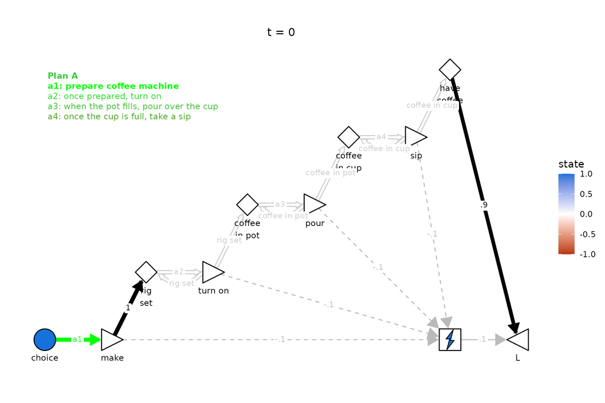

```r
steps  <- nrow(out$trajectory) - 1L
frames <- lapply(0:steps, function(t) {
  plotField(model_full, field$params, out$trajectory[paste0("t=", t), ],
            layout, plan = planA, plan_ramp = TRUE,
            condition_ramp = TRUE, title = paste("t =", t))
})

plotsAsWidget(
  frames,
  panel_titles = paste("Step", 0:steps),
  width = 9, height = 6
)
```

Frame 1 of 5

## Step 6: Where a faulty plan breaks

```r
out_np <- simulateF(field$model, field$params, s_0, planB, flows = "choice")
round(out_np$trajectory[, c("make","s2","TurnOn","HCoPot","Pour",
                            "HCoCup","Sip","HCo","Energy","L")], 2)
```

```
#>     make s2 TurnOn HCoPot Pour HCoCup Sip HCo Energy     L
#> t=0    0  0      0      0    0      0   0   0    0.0  0.00
#> t=1    1  1      0      0    0      0   0   0   -0.1 -0.01
#> t=2    0  0      1      1    0      0   0   0   -0.2 -0.02
```

```r
out_np$fired
```

```
#> [1] "make"   "TurnOn"
```

The token climbs two stages — `make` sets up the rig, `TurnOn` brews `HCoPot` — and then **stops**. With no pour rule, `Pour` is never eligible, so the coffee sits in the pot, the cup is never filled, and the run goes quiescent with `HCo` never reached. The two actions taken have already cost `Energy = -0.2`, so the readout settles **negative** (`L = -0.02`). Stepping through, the lit node climbs to **coffee in pot** and halts — the staircase ends mid-flight:

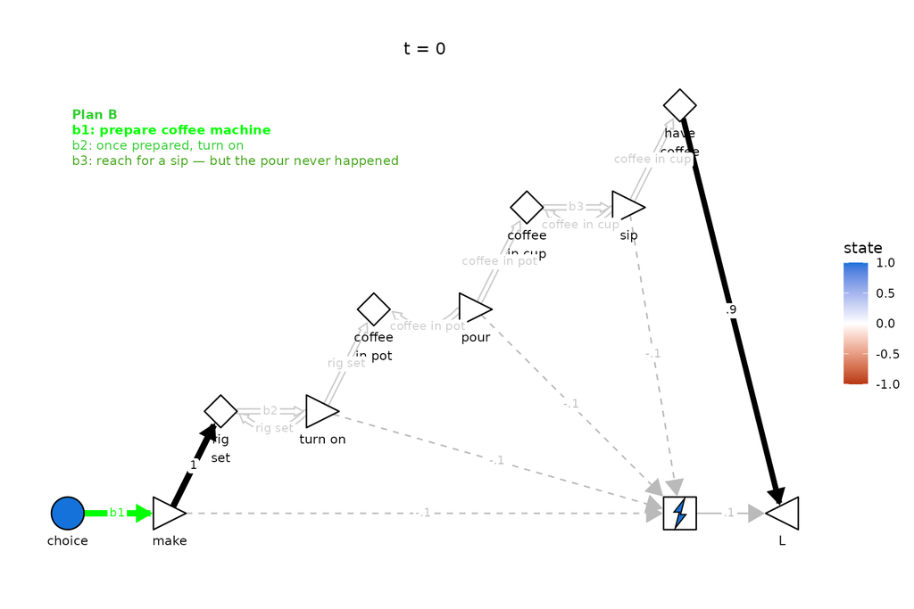

```r
model_np  <- paste(field$model, planB$policy, sep = "\n")
steps_np  <- nrow(out_np$trajectory) - 1L
frames_np <- lapply(0:steps_np, function(t) {
  plotField(model_np, field$params, out_np$trajectory[paste0("t=", t), ],
            layout, plan = planB, plan_ramp = TRUE,
            condition_ramp = TRUE, title = paste("t =", t))
})

plotsAsWidget(
  frames_np,
  panel_titles = paste("Step", 0:steps_np),
  width = 9, height = 6
)
```

Frame 1 of 3

Tellingly, the pour *affordance* stays open: because there is coffee in the pot, the `Pour → coffee-in-cup` force (and its consumption arc back to the pot) are still drawn — and **lit gold**, since *coffee in pot* is a met condition — yet they leave a **white `pour` node**, because the green action that would fill it never fires. The move is available and the field would reward it; the policy simply never calls it. That gap is the whole failure: one missing rule, and everything downstream of it stays unlit. The run doesn’t error or stall on a technicality — it **runs out of eligible actions**, which is exactly what a broken plan is.

## Step 7: Blowing out the prep — parallel, any-order actions

So far every action had exactly one predecessor: the pipeline self-ordered through gating. Real plans are rarely so linear. The single `make` step compressed all of *setting up the coffee maker* into one move; blow it out into the five things that actually have to happen — add water, add grounds, add a filter, plug it in, set the pot under it — and two new features of action appear:

- the five preps can be done in **any order** (they don’t depend on each other), and
- the machine brews only once **all five** are done (a **conjunction**).

Each prep is an action producing its own state. “Prepped” is the AND of all five — and since `lavaan` interactions are only pairwise, `andF()` builds that five-way conjunction two at a time, returning the model fragment and the names of the **derived** nodes it introduces:

```r
preps    <- c("AddWater", "AddGrounds", "AddFilter", "PlugIn", "AddPot")
haves    <- c("HasWater", "HasGrounds", "HasFilter", "HasPower", "HasPot")
actions2 <- c(preps, "TurnOnCM", "Pour", "Sip")

prepped <- andF("Prepped", haves)
cat(prepped$model)
```

```
#> Prepped1 ~ 1 * HasWater:HasGrounds
#> Prepped2 ~ 1 * Prepped1:HasFilter
#> Prepped3 ~ 1 * Prepped2:HasPower
#> Prepped ~ 1 * Prepped3:HasPot
```

```r
prepped$aux
```

```
#> [1] "Prepped1" "Prepped2" "Prepped3" "Prepped"
```

```r
field2 <- labelF(paste("
  HasWater   ~ 1 * AddWater + use * HasWater:TurnOnCM
  HasGrounds ~ 1 * AddGrounds
  HasFilter  ~ 1 * AddFilter
  HasPower   ~ 1 * PlugIn
  HasPot     ~ 1 * AddPot",
  prepped$model,
  "HCoPot ~ 1 * Prepped:TurnOnCM + use * HCoPot:Pour
   HCoCup ~ 1 * HCoPot:Pour      + use * HCoCup:Sip
   HCo    ~ 1 * HCoCup:Sip",
  costF(actions2, cost = -0.1),
  "L ~ 0.9 * HCo + 0.1 * Energy", sep = "\n"),
  actions = actions2)
field2$params["use"] <- -1
```

Brewing (`TurnOnCM`) is gated on `Prepped` and *uses up the water*, which un-prepares the machine so it can’t re-brew. The agent’s plan is a **to-do list**: five one-shot intentions, one per prep, plus the usual brew / pour / sip rules. Because all five intentions are live at the start, all five preps are eligible at once:

```r
policy2 <- "
  AddWater   ~ toWater
  AddGrounds ~ toGrounds
  AddFilter  ~ toFilter
  PlugIn     ~ toPower
  AddPot     ~ toPot
  TurnOnCM   ~ Prepped
  Pour       ~ HCoPot
  Sip        ~ HCoCup
"
todo <- c(toWater = 1, toGrounds = 1, toFilter = 1, toPower = 1, toPot = 1)
s2_0 <- c(todo,
          setNames(rep(0, length(haves)), haves),
          setNames(rep(0, length(prepped$aux)), prepped$aux),
          setNames(rep(0, length(actions2)), actions2),
          HCoPot = 0, HCoCup = 0, HCo = 0, Energy = 0, L = 0)
```

Run it. `aux = prepped$aux` tells `simulateF()` those conjunction nodes are **derived** — recomputed each turn from the current states rather than latching — and `flows` marks the five to-do tokens as one-shot:

```r
out2 <- simulateF(field2$model, field2$params, s2_0, policy2,
                  aux = prepped$aux, flows = names(todo), max_turns = 20)
round(out2$trajectory[, c("HasWater","HasGrounds","HasFilter","HasPower",
                          "HasPot","Prepped","HCoPot","HCoCup","HCo","Energy","L")], 2)
```

```
#>     HasWater HasGrounds HasFilter HasPower HasPot Prepped HCoPot HCoCup HCo
#> t=0        0          0         0        0      0       0      0      0   0
#> t=1        1          0         0        0      0       0      0      0   0
#> t=2        1          1         0        0      0       0      0      0   0
#> t=3        1          1         1        0      0       0      0      0   0
#> t=4        1          1         1        1      0       0      0      0   0
#> t=5        1          1         1        1      1       1      0      0   0
#> t=6        0          1         1        1      1       0      1      0   0
#> t=7        0          1         1        1      1       0      0      1   0
#> t=8        0          1         1        1      1       0      0      0   1
#>     Energy     L
#> t=0    0.0  0.00
#> t=1   -0.1 -0.01
#> t=2   -0.2 -0.02
#> t=3   -0.3 -0.03
#> t=4   -0.4 -0.04
#> t=5   -0.5 -0.05
#> t=6   -0.6 -0.06
#> t=7   -0.7 -0.07
#> t=8   -0.8  0.82
```

```r
out2$fired
```

```
#> [1] "AddWater"   "AddGrounds" "AddFilter"  "PlugIn"     "AddPot"
#> [6] "TurnOnCM"   "Pour"       "Sip"
```

The five preps fire one per turn (turns 1–5), `Prepped` flips on the moment the last one lands, brewing fills the pot at turn 6, and pour / sip finish the job — eight actions, so `Energy = -0.8` and `L = 0.82`. Two things are worth drawing out:

- **The order is genuinely arbitrary.** When several actions are eligible, the choice node appraises each one turn ahead and takes the best — but no single prep moves `L` (you need all five *and* the brew), so the appraisal is **indifferent**, and the tie is broken by listing order. Any permutation of the five reaches the same prepped machine and the same final `L`. This is the first time the per-turn appraisal faces a real tie; the linear pipeline never did.
- **`Prepped` is a derived node, not a stock.** It is a pure function of the five states, so it recomputes every turn (passed via `aux`) and `simulateF()` resolves the whole conjunction chain within a single turn. The moment water is consumed at brew time, `Prepped` falls back to `0`.

Drawn, the process is a **fan into a staircase**: five parallel preps merge into `Prepped`, then the familiar linear brew → pour → sip. The merge edges are **conjunctive** — `Prepped` fires only when *all* five hold — so `plotField()` draws them **dotted** (a product), rather than the solid numeric edges of an additive relationship, which would misleadingly read as regression weights. (For the diagram we show the conjunction as a direct five-way merge; under the hood it is the pairwise chain `andF()` built.)

The five preps are a single *phase* of any-order moves rather than an ordered sequence, so they don’t slot cleanly into the `a1, a2, …` numbering a linear plan gets. A natural extension is to label such a phase with a shared step and a sub-letter — `a1a, a1b, a1c, …` for the interchangeable preps — which a later turn on the plan object will support; for now this fan is drawn without a corner plan-list.

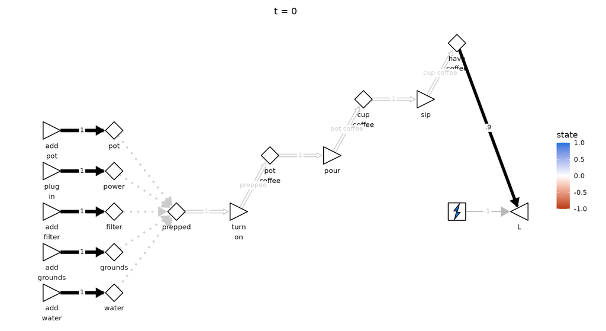

```r
disp2 <- "
  HasWater ~ 1*AddWater
  HasGrounds ~ 1*AddGrounds
  HasFilter ~ 1*AddFilter
  HasPower ~ 1*PlugIn
  HasPot ~ 1*AddPot
  Prepped ~ 1*HasWater + 1*HasGrounds + 1*HasFilter + 1*HasPower + 1*HasPot
  HCoPot ~ 1*Prepped:TurnOnCM
  HCoCup ~ 1*HCoPot:Pour
  HCo ~ 1*HCoCup:Sip
  L ~ 0.9*HCo + 0.1*Energy"
disp_pol2   <- "TurnOnCM ~ 1*Prepped\nPour ~ 1*HCoPot\nSip ~ 1*HCoCup"
disp_model2 <- paste(disp2, disp_pol2, sep = "\n")

# The five preps are smushed into a fan in the bottom-left, with `Prepped` in
# the vertical middle of that group; from there a rising staircase carries
# brew -> pour -> sip (policy edges level, production forces diagonally up),
# and `L` drops back to the staircase's base level.
py <- c(0, 1.3, 2.6, 3.9, 5.2)            # prep-group rows; middle = 2.6
layout2 <- data.frame(
  name  = c(preps, haves, "Prepped","TurnOnCM","HCoPot","Pour",
            "HCoCup","Sip","HCo","Energy","L"),
  x     = c(rep(0,5), rep(2,5), 4, 6, 7, 9, 10, 12, 13, 13, 15),
  y     = c(py, py, 2.6, 2.6, 4.4, 4.4, 6.2, 6.2, 8.0, 2.6, 2.6),
  shape = c(rep("rtTri",5), rep("diamond",5), "diamond","rtTri","diamond",
            "rtTri","diamond","rtTri","diamond","square","lfTri"),
  label = c("add\nwater","add\ngrounds","add\nfilter","plug\nin","add\npot",
            "water","grounds","filter","power","pot","prepped","turn\non",
            "pot\ncoffee","pour","cup\ncoffee","sip","have\ncoffee","Energy","L"),
  glyph = c(rep(NA,17), "⚡", NA),
  stringsAsFactors = FALSE)

steps2  <- nrow(out2$trajectory) - 1L
frames2 <- lapply(0:steps2, function(t) {
  plotField(disp_model2, numeric(0), out2$trajectory[paste0("t=", t), ],
            layout2, plan = disp_pol2, plan_ramp = TRUE, condition_ramp = TRUE,
            conjunctive = "Prepped", node_size = 0.28, title = paste("t =", t))
})

plotsAsWidget(frames2, panel_titles = paste("Step", 0:steps2),
              width = 11, height = 6)
```

Frame 1 of 9

## Step 8: Unpacking the conjunction into a process

Step 7 compressed the whole coffee maker into a single conjunction: five conditions met, `Prepped` fires, one `TurnOnCM` step turns the prepped machine into a pot of coffee. But a drip machine does not check five boxes and brew in a single motion — it runs a *sequence*, and each condition enters the story at its own stage. Power heats the plate; the hot plate boils the water; the hot water wets the grounds; the steeped slurry drips through the filter; the drips collect in the pot. The single `turn on -> pot coffee` step is itself a little process, and we can **blow it up** the same way we blew up the prep — except this time the five conditions are not interchangeable, they are *ordered gates* along a chain.

Each stage is an **internal action** of the machine: a prior machine-state drives an action which, gated by the relevant condition, produces the next machine-state and empties the one before it — `[state -> action -> state]`, one rung per turn. These are the machine’s own moves rather than the agent’s, so they cost no effort; the agent’s one overt act is pressing the button.

```r
machine  <- c("IsHotCM", "HotWaterCM", "HotSlurryCM", "DripCoffeeCM")
actions3 <- c(preps, "TurnOnCM", "heatW", "wetG", "drip", "fill")
prepped3 <- andF("Prepped", haves)          # the AND, built pairwise as before

field3 <- labelF(paste("
  HasWater   ~ 1 * AddWater + use * HasWater:heatW
  HasGrounds ~ 1 * AddGrounds
  HasFilter  ~ 1 * AddFilter
  HasPower   ~ 1 * PlugIn
  HasPot     ~ 1 * AddPot
  IsHotCM      ~ 1 * HasPower:TurnOnCM  + use * IsHotCM:heatW
  HotWaterCM   ~ 1 * HasWater:heatW     + use * HotWaterCM:wetG
  HotSlurryCM  ~ 1 * HasGrounds:wetG    + use * HotSlurryCM:drip
  DripCoffeeCM ~ 1 * HasFilter:drip     + use * DripCoffeeCM:fill
  HCoPot       ~ 1 * HasPot:fill",
  prepped3$model,
  costF(c(preps, "TurnOnCM"), cost = -0.1),
  "L ~ 0.9 * HCoPot + 0.1 * Energy", sep = "\n"),
  actions = actions3)
field3$params["use"] <- -1
```

Two choices make the chain **self-limiting** without any one-shot token. Brewing is gated on the full conjunction (`TurnOnCM ~ Prepped`), and heating **consumes the water** — it boils out of the reservoir and through the machine (`use * HasWater:heatW`). The moment `heatW` fires the water is gone, `Prepped` is no longer satisfied, and the button cannot start a second brew.

```r
policy3 <- "
  AddWater   ~ toWater
  AddGrounds ~ toGrounds
  AddFilter  ~ toFilter
  PlugIn     ~ toPower
  AddPot     ~ toPot
  TurnOnCM   ~ Prepped
  heatW      ~ IsHotCM
  wetG       ~ HotWaterCM
  drip       ~ HotSlurryCM
  fill       ~ DripCoffeeCM
"
s3_0 <- c(todo,
          setNames(rep(0, length(haves)),        haves),
          setNames(rep(0, length(prepped3$aux)), prepped3$aux),
          setNames(rep(0, length(machine)),      machine),
          setNames(rep(0, length(actions3)),     actions3),
          HCoPot = 0, Energy = 0, L = 0)
```

`aux = prepped3$aux` again marks the conjunction nodes as derived; the machine states are ordinary latching stocks, each emptied by the next internal action.

```r
out3 <- simulateF(field3$model, field3$params, s3_0, policy3,
                  aux = prepped3$aux, flows = names(todo), max_turns = 20)
round(out3$trajectory[, c("HasWater", "Prepped", "IsHotCM", "HotWaterCM",
                          "HotSlurryCM", "DripCoffeeCM", "HCoPot", "L")], 2)
```

```
#>      HasWater Prepped IsHotCM HotWaterCM HotSlurryCM DripCoffeeCM HCoPot     L
#> t=0         0       0       0          0           0            0      0  0.00
#> t=1         1       0       0          0           0            0      0 -0.01
#> t=2         1       0       0          0           0            0      0 -0.02
#> t=3         1       0       0          0           0            0      0 -0.03
#> t=4         1       0       0          0           0            0      0 -0.04
#> t=5         1       1       0          0           0            0      0 -0.05
#> t=6         1       1       1          0           0            0      0 -0.06
#> t=7         0       0       0          1           0            0      0 -0.06
#> t=8         0       0       0          0           1            0      0 -0.06
#> t=9         0       0       0          0           0            1      0 -0.06
#> t=10        0       0       0          0           0            0      1  0.84
```

```r
out3$fired
```

```
#>  [1] "AddWater"   "AddGrounds" "AddFilter"  "PlugIn"     "AddPot"
#>  [6] "TurnOnCM"   "heatW"      "wetG"       "drip"       "fill"
```

The five preps go first, in any order, then `TurnOnCM` heats the plate. From there the machine climbs on its own — `heatW`, `wetG`, `drip`, `fill`, one rung per turn — and the run halts the moment coffee reaches the pot, ten turns in. Watch `HasWater` and `Prepped`: both fall to `0` at the heating step, which is why the button never fires twice. (The button’s energy cost helps too: on the one turn that both the button and `heatW` are eligible, the free machine step yields the slightly higher `L`, so the machine advances rather than re-brewing.)

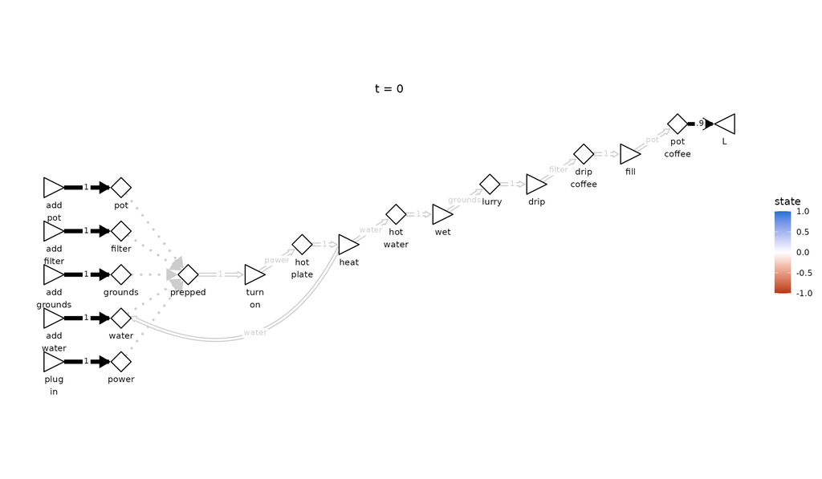

```r
disp3 <- "
  HasWater   ~ 1*AddWater + -1*HasWater:heatW
  HasGrounds ~ 1*AddGrounds
  HasFilter  ~ 1*AddFilter
  HasPower   ~ 1*PlugIn
  HasPot     ~ 1*AddPot
  prepped ~ 1*HasWater + 1*HasGrounds + 1*HasFilter + 1*HasPower + 1*HasPot
  IsHotCM      ~ 1*HasPower:TurnOnCM
  HotWaterCM   ~ 1*HasWater:heatW
  HotSlurryCM  ~ 1*HasGrounds:wetG
  DripCoffeeCM ~ 1*HasFilter:drip
  HCoPot       ~ 1*HasPot:fill
  L ~ 0.9*HCoPot"
disp_pol3 <- "
  TurnOnCM ~ 1*prepped
  heatW ~ 1*IsHotCM
  wetG  ~ 1*HotWaterCM
  drip  ~ 1*HotSlurryCM
  fill  ~ 1*DripCoffeeCM"
disp_model3 <- paste(disp3, disp_pol3, sep = "\n")

# `prepped` is now inert; show it as the AND of the five conditions (blue while
# they all hold, white once heating spends the water).
condcols <- c("HasWater", "HasGrounds", "HasFilter", "HasPower", "HasPot")
traj3 <- cbind(out3$trajectory,
               prepped = apply(out3$trajectory[, condcols], 1, prod))

# Left fan as in Step 7, but the conditions are ordered by their place in the
# PROCESS (power lowest ... pot highest) so the fan ascends in step with the
# risers. The single brew arrow is blown up into a staircase: treads
# (condition -> action) level, risers (action -> condition) diagonally up.
fy <- c(1.3, 2.6, 3.9, 0, 5.2)            # rows for water, grounds, filter, power, pot
bx <- 6; by <- 2.6; run <- 1.4; rise <- 0.9
ax <- function(k) bx + (k - 1) * 2 * run; ay <- function(k) by + (k - 1) * rise
yx <- function(k) ax(k) + run;            yy <- function(k) ay(k) + rise
layout3 <- data.frame(
  name = c(preps, haves, "prepped",
           "TurnOnCM", "heatW", "wetG", "drip", "fill",
           "IsHotCM", "HotWaterCM", "HotSlurryCM", "DripCoffeeCM", "HCoPot", "L"),
  x = c(rep(0, 5), rep(2, 5), 4, ax(1:5), yx(1:5), yx(5) + run),
  y = c(fy, fy, 2.6, ay(1:5), yy(1:5), yy(5)),
  shape = c(rep("rtTri", 5), rep("diamond", 5), "diamond",
            rep("rtTri", 5), rep("diamond", 5), "lfTri"),
  label = c("add\nwater", "add\ngrounds", "add\nfilter", "plug\nin", "add\npot",
            "water", "grounds", "filter", "power", "pot", "prepped",
            "turn\non", "heat", "wet", "drip", "fill",
            "hot\nplate", "hot\nwater", "slurry", "drip\ncoffee", "pot\ncoffee", "L"),
  stringsAsFactors = FALSE)

steps3  <- nrow(traj3) - 1L
frames3 <- lapply(0:steps3, function(t) {
  plotField(disp_model3, numeric(0), traj3[paste0("t=", t), ], layout3,
            plan = disp_pol3, plan_ramp = TRUE, condition_ramp = TRUE,
            conjunctive = "prepped", node_size = 0.30, title = paste("t =", t))
})
plotsAsWidget(frames3, panel_titles = paste("Step", 0:steps3),
              width = 12, height = 7)
```

Frame 1 of 11

The conditions, ordered bottom-to-top by their place in the process, each light their own riser in their own amber; `prepped` sits inert at the elbow, blue while the five hold and white the instant the water is spent. The long dashed arc curving from `heat` back to `water` is that water leaving — the one consumption that, by breaking the conjunction, keeps the brew to a single pot. This is a first pass at the expansion: the machine’s other ingredients are not yet spent the way the water is, so the process model is faithful in shape more than in full bookkeeping — a thread to pull on later.

## Consumption is what keeps a field bounded

`simulateF()` does **not** clamp. Functional-field state is expected to stay within `[-1, 1]`; a value outside it signals a misspecification rather than something to silently truncate. The clearest way to trip it is to give a stock an inflow but no consumption — and a policy that keeps firing the action that feeds it. With nothing to use the stock up, it accumulates without bound and the run never goes quiescent:

```r
runaway <- simulateF("tank ~ 1 * pump", params = numeric(0),
                     s_0 = c(on = 1, pump = 0, tank = 0),
                     policy = "pump ~ on", max_turns = 4)
```

```
#> Warning: simulateF: |state| > 1 at turn 2 (possible misspecification): tank=2
#> Warning: simulateF: |state| > 1 at turn 3 (possible misspecification): tank=3
#> Warning: simulateF: |state| > 1 at turn 4 (possible misspecification): tank=4
```

```r
runaway$trajectory[, "tank"]
```

```
#> t=0 t=1 t=2 t=3 t=4
#>   0   1   2   3   4
```

The warning names the offending node and turn, and the true (un-clamped) value is returned so the overshoot is visible. In the coffee field the `use` terms are exactly what keep every stock bounded: each stage hands its token on and empties, so nothing piles up — and the run *ends*, because once everything is consumed, nothing is eligible.

## Takeaway

One **field**, one **policy**, one **run**. The field is the physics — how actions produce and consume states, what they cost, and what the agent values; the policy is the plan — which action is allowed when; and `simulateF()` plays the policy on the field one action at a time. Because actions enter singly and exogenously, the same run is both the *equilibrium read* (its final `L` is what the plan affords) and the *temporal read* (its trajectory is how the plan unfolds) — there is no separate mode for the two questions.

The same machinery generalises beyond one agent: a turn need not always belong to the same actor. Let agent **A** act, the field re-settle, and agent **B** appraise the *changed* field and respond — and you have a two-party interaction in the same engine. That is the subject of a later vignette. The inductive direction — recovering the field’s coefficients from data — is the subject of the `pathXMY` vignettes (`vignette("speeding_pathXMY", package = "funfield")` and its companions). ```